# Segundo paso: Decision Tree

Alejandro Bolaños

2018-09-02

> “If you torture the data long enough, it will confess.” — Ronald Coase

- Train/Test
- Cross Validation
- Monte Carlo Cross Validation

Haremos foco en la última. Pero, para empezar a generar las muestras aleatórias, debemos contar un con conjunto de `semillas` para poder reproducir las pruebas.

Quizás sea un poco un exageración, pero tomemos un conjunto de números 100% aleatorios (algo que no se puede lograr por medio de algoritmos). Tomemos 100:

```r
rm( list=ls() )
gc()
```

```
##          used (Mb) gc trigger (Mb) max used (Mb)
## Ncells 447181 23.9     963738 51.5   627842 33.6
## Vcells 870685  6.7    8388608 64.0  1751914 13.4
```

```r
library(data.table)

x <- fread("https://www.random.org/integer-sets/?sets=1&num=100&min=100000&max=1000000&commas=on&order=index&format=plain&rnd=new")

v_semillas <- as.vector(unlist(x))
v_semillas
```

```
##   [1] 371132 810757 802402 920661 482071 309450 453483 156134 455625 519384
##  [11] 492997 589952 712559 637095 340979 478366 604484 504822 899942 384026
##  [21] 549989 598382 715272 723004 733253 822326 957635 584103 127841 950949
##  [31] 138872 926575 991760 485499 451973 105772 608543 472475 446441 551220
##  [41] 558104 631325 424040 917513 302955 117800 492333 558850 604948 153029
##  [51] 809321 347110 559981 817501 813516 660348 935852 275830 923913 622440
##  [61] 654523 757038 395213 491459 782074 721163 688799 815116 732807 890342
##  [71] 151095 955909 986581 867081 925740 465735 581375 298800 368321 978285
##  [81] 612444 294501 336554 254210 977686 442560 637473 484363 780440 242143
##  [91] 770391 598537 935909 546223 146500 797449 153294 866056 686436 499801
```

Veamos cuantos números primos obtuvimos en esta lista de números aleatorios:

```r
# install.packages("numbers")
library(numbers)
v_semillas_primos <- v_semillas[isPrime(v_semillas)]

v_semillas_primos
```

```
##  [1] 810757 482071 340979 446441 917513 721163 688799 986581 598537 499801
```

Ejercicio: Pruebe sucesivamente bajar de forma aleatoria números entre 100.000 y 1.000.000. Note que siempre hay un porcentaje similiar de números primos. ¿Cualés son los motivos de este embrujo? Acérquese ligeramente de la Teoría de números. Tenga cuidado, quizás lo asuste y salga corriendo… quizás lo enamoré y no le deje volver al data science.

Primero, levantemos nuestro conjunto de datos y construyamos la clase binaria sobre la que trabajaremos:

```r
febrero  <-  fread("../cloud/cloud1/datasets/201902.txt", header=TRUE, sep="\t")

febrero[, clase_binaria := ifelse(clase_ternaria == "BAJA+2", "1", "0")]

# Sacamos la clase ternaria
febrero[, clase_ternaria:= NULL]

# Lo mismo con el ID del cliente
febrero[, numero_de_cliente:= NULL]
```

Y simplemente cortamos en Train/Test nuestro conjunto de datos:

```r
library(caret)
semilla <- v_semillas_primos[1]
set.seed(semilla)
inTraining <- createDataPartition( febrero[, get("clase_binaria")], p = 0.70, list = FALSE)
febrero_training  <-  febrero[  inTraining, ]
febrero_testing   <-  febrero[ -inTraining, ]
```

Nuevamente generamos un modelo, pero ahora solo para el entrenamiento, aplicamos el modelo en el conjunto de prueba:

```r
library(rpart)
library( "rpart.plot" )

modelo_oos <- rpart(clase_binaria ~ ., data = febrero_training,   cp=0.001,  xval=0 )
```

Y aplicamos la predicción con el modelo generado, sobre las muestras que particionamos anteriormente:

```r
pred_training <- predict(modelo_oos, febrero_training , type = "prob")
pred_testing <- predict(modelo_oos, febrero_testing , type = "prob")

pred_testing <- as.data.frame(pred_testing)
pred_training <- as.data.frame(pred_training)
head(pred_training)
```

|  | 0 | 1 |
| --- | --- | --- |
| 1 | 0.996318 | 0.003681961 |
| 2 | 0.996318 | 0.003681961 |
| 3 | 0.996318 | 0.003681961 |
| 4 | 0.996318 | 0.003681961 |
| 5 | 0.996318 | 0.003681961 |
| 6 | 0.996318 | 0.003681961 |

Ahora, en vez de calcular a mano nuestras métricas, usemos el soporte de las librerías, de esta forma:

```r
library( "ROCR" )
```

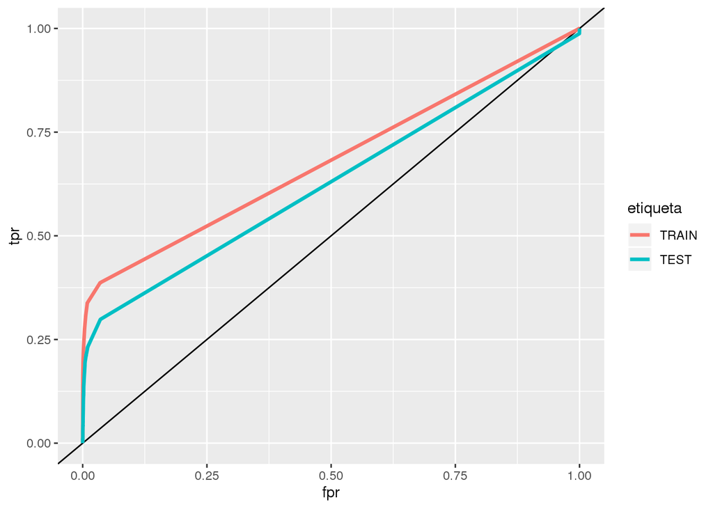

```r
# Train
roc_train <- ROCR::prediction(  pred_training$`1`, febrero_training$clase_binaria, label.ordering=c( 0, 1))
auc_train  <-  ROCR::performance( roc_train,"auc");
roc_train <- ROCR::performance(roc_train,"tpr","fpr")

# Test
roc_test <- ROCR::prediction(  pred_testing$`1`, febrero_testing$clase_binaria, label.ordering=c( 0, 1))
auc_test  <-  ROCR::performance( roc_test,"auc");
roc_test <- ROCR::performance(roc_test,"tpr","fpr")

plotdat_train <- data.frame(fpr=roc_train@x.values[[1]],tpr=roc_train@y.values[[1]],CUT=roc_train@alpha.values[[1]],etiqueta="TRAIN")
plotdat_test <- data.frame(fpr=roc_test@x.values[[1]],tpr=roc_test@y.values[[1]],CUT=roc_test@alpha.values[[1]],etiqueta="TEST")

plotdat <- rbind(plotdat_train,plotdat_test)

ggplot(plotdat, aes(x=fpr,y=tpr)) +
  geom_abline(intercept=0,slope=1) +
  geom_line(aes(colour = etiqueta), size = 1.2)
```

Y obtenemos el `AUC` de cada conjunto:

```r
# El de entrenamiento
auc_train@y.values
```

```
## [[1]]
## [1] 0.6811587
```

```r
# El de test
auc_test@y.values
```

```
## [[1]]
## [1] 0.6288108
```

`ROCR` cuenta con muchas métricas. Explore la librería y vea si le puede ser útil como otras métricas.

Es interesante ver que como intuíamos en la clase pasada, hay presencia de *overfitting* en nuestro árbol. Veamos como afecta a la ganancia este fenómeno. Definamos una función para el cálculo de ganancia que nos acompañe en resto de los cálculos (manteniendo el punto de corte en 0.025… por ahora):

```r
fganancia = function(probabilidades, clase, punto_corte=0.025) {
  return(sum(
    (probabilidades >= punto_corte) * ifelse( clase == "1", 19500, -500 ))
  )
}

# Ganancia en el conjunto de entrenamiento
fganancia(pred_training$`1`, febrero_training$clase_binaria)
```

```
## [1] 4401500
```

```r
# Ganancia en el conjunto de prueba
fganancia(pred_testing$`1`, febrero_testing$clase_binaria)
```

```
## [1] 1192000
```

Ahhh claro, como las cantidades de los conjuntos de datos son distintas, igual van a ser sus ganancias. Normalicemos las ganancias en función de su proporción:

```r
# Ganancia en el conjunto de entrenamiento
fganancia(pred_training$`1`, febrero_training$clase_binaria)/0.7
```

```
## [1] 6287857
```

```r
# Ganancia en el conjunto de prueba
fganancia(pred_testing$`1`, febrero_testing$clase_binaria)/0.3
```

```
## [1] 3973333
```

Observamos que el overfitting se observa en la ganancia, y hasta se podría intuir que le afecta más a este indicador que a las `AUC`.

Pero antes de ver como podemos mejorar el *overfitting*, veamos otro fenómeno interesante. Modelemos, pero probando distintas semillas.

En términos biológicos, de dos semillas obtenemos dos árboles parecidos pero no iguales. ¿Sucederá lo mismo en nuestros modelos? No hay más de probar…

```r
resultados <- data.table()

for( s in  v_semillas_primos[1:5] ) {

    set.seed( s )
    inTraining <- createDataPartition( febrero[, get("clase_binaria")], p = 0.70, list = FALSE)
    febrero_training  <-  febrero[  inTraining, ]
    febrero_testing   <-  febrero[ -inTraining, ]

    modelo_oos <- rpart(clase_binaria ~ ., data = febrero_training,   cp=0.001,  xval=0 )

    # Si deseamos ver que tan distintos son los árboles genererados, descomentar la línea de abajo:
    # prp( modelo_oos, extra=101, digits=5, branch=1, type=4, varlen=0, faclen=0 )

    pred_training <- predict(modelo_oos, febrero_training , type = "prob")
    pred_testing <- predict(modelo_oos, febrero_testing , type = "prob")

    pred_testing <- as.data.frame(pred_testing)
    pred_training <- as.data.frame(pred_training)

    # Train
    roc_train <- ROCR::prediction(  pred_training$`1`, febrero_training$clase_binaria, label.ordering=c( 0, 1))
    auc_train  <-  ROCR::performance( roc_train,"auc");

    # Test
    roc_test <- ROCR::prediction(  pred_testing$`1`, febrero_testing$clase_binaria, label.ordering=c( 0, 1))
    auc_test  <-  ROCR::performance( roc_test,"auc");

    resultados <-   rbindlist(
                      list(resultados,
                           data.frame(semilla=s,type= "train",
                                   auc=unlist(auc_train@y.values),
                                   ganancia=fganancia(pred_training$`1`, febrero_training$clase_binaria)),
                           data.frame(semilla=s,type= "test",
                                   auc=unlist(auc_test@y.values),
                                   ganancia=fganancia(pred_testing$`1`, febrero_testing$clase_binaria))
                        )
                    )
}

resultados
```

| semilla | type | auc | ganancia |
| --- | --- | --- | --- |
| 810757 | train | 0.6811587 | 4401500 |
| 810757 | test | 0.6288108 | 1192000 |
| 482071 | train | 0.7416113 | 5295500 |
| 482071 | test | 0.7086203 | 1872500 |
| 340979 | train | 0.8079322 | 5734000 |
| 340979 | test | 0.7782145 | 2088000 |
| 446441 | train | 0.6647861 | 3533500 |
| 446441 | test | 0.6740839 | 1637000 |
| 917513 | train | 0.8172973 | 4846500 |
| 917513 | test | 0.8248933 | 2088000 |

```r
resultados[type == "test",]
```

| semilla | type | auc | ganancia |
| --- | --- | --- | --- |
| 810757 | test | 0.6288108 | 1192000 |
| 482071 | test | 0.7086203 | 1872500 |
| 340979 | test | 0.7782145 | 2088000 |
| 446441 | test | 0.6740839 | 1637000 |
| 917513 | test | 0.8248933 | 2088000 |

Vemos dos importantes fenómenos, el primero es la gran variación de resultados producto de cambiar de semilla!. Además nos damos cuenta que la métrica `AUC` y `GANANCIA` no van de la mano. ¿Por qué?

- ¿Qué debemos hacer?
- ¿Elegir la mejor semilla?
- ¿Llorar y plantearnos nuestro lugar en el mundo?
- ¿Se puede conseguir métricas de mayor confianza frente a este panorama?

```r
resultados[, list(gan_media=mean(ganancia),gan_min=min(ganancia), gan_max=max(ganancia)) , by=type]
```

| type | gan_media | gan_min | gan_max |
| --- | --- | --- | --- |
| train | 4762200 | 3533500 | 5734000 |
| test | 1775500 | 1192000 | 2088000 |

```r
resultados[type=="test", list(gan_media=mean(ganancia)/0.3,
                              gan_min=min(ganancia)/0.3,
                              gan_max=max(ganancia)/0.3) , by=type]
```

| type | gan_media | gan_min | gan_max |
| --- | --- | --- | --- |
| test | 5918333 | 3973333 | 6960000 |

[figure not shown]

STOP

Empezaremos a usar con cada vez más frecuencia el uso de funciones. Las funciones tienen muchos buenos atributos, y si ustedes las absorben como herramienta e incluso las generan, estarán un paso adelante. No hay forma de experimentar de forma consistente, sin usar código prolijo.

Con esta aclaración, empecemos adaptando nuestro trabajo anterior a una forma más programática de pensar.

Para simplificar nuestro trabajo vamos a definir una función que nos calcule las métricas de nuestro modelo (podremos ampliar la misma más adelante para incluir nuevas)

```r
fmetricas <- function(probs, clases, cutoff=0.025, proporcion=1, label="", type="", semilla=NA) {

  # AUC
  binaria  <-  as.numeric(clases == "1")
  roc_pred <-  ROCR::prediction(probs, binaria, label.ordering=c( 0, 1))
  auc_t <-  ROCR::performance( roc_pred,"auc");
  auc <- unlist(auc_t@y.values)

  # Ganancia
  ganancia <- fganancia(probs, binaria)

  # Ganancia normalizada, proyectamos la ganancia según el porcentaje de la muestra.
  ganancia_normalizada <- ganancia / proporcion

  return(data.table(label, semilla, type, ganancia, ganancia_normalizada, auc))
}
```

Y probamos su uso, con los datos de la última ejecución del loop anterior:

```r
fmetricas(pred_testing$`1`, febrero_testing$clase_binaria,proporcion=0.3, label="arbol", type="test", semilla=s)
```

| label | semilla | type | ganancia | ganancia_normalizada | auc |
| --- | --- | --- | --- | --- | --- |
| arbol | 917513 | test | 2088000 | 6960000 | 0.8248933 |

- ¿Qué otras métricas, simples o complejas, le puede ayudar para entender y *comparar* los modelos?
- Haga suya esta función y complete con todo lo que usted necesita saber entender mejor sus experimentos.

> An economist is an expert who will know tomorrow why the things he predicted yesterday didn’t happen today. — LAURENCE J. PETER

Veamos otro tipo de conjunto de validación, *OOT* o `Out of Time`. A mi entender es el más importante, ya que es el que nos brinda más tranquilidad de que el modelo va a ser robusto en las ejecuciones de los siguientes meses que aún no transcurrieron.

Para lo mismo debemos contemplar que no haya variables del tipo `DATE` o `DATETIME`. ¿Por qué? ¿Afectan estás variables en la performance de un OOS?

Para transformar las variables, el profesor creo un script que nos automatiza el trabajo. *Mirar detenidamente el script y comprenderlo, hacerlo propio.*

Sumaremos en las métricas la capacidad de determinar el punto de corte en función de los conjuntos de validación.

```r
abril <-  fread("../cloud/cloud1/datasets/201904.txt", header=TRUE, sep="\t")

fmetricas <- function(probs, clases, cutoff=0.025, proporcion=1, label="", type="", semilla=NA) {

  # AUC
  binaria  <-  as.numeric(clases == "1")
  roc_pred <-  ROCR::prediction(probs, binaria, label.ordering=c( 0, 1))
  auc_t <-  ROCR::performance( roc_pred,"auc");
  auc <- unlist(auc_t@y.values)

  # Ganancia
  ganancia <- fganancia(probs, binaria)

  # Ganancia normalizada, proyectamos la ganancia según el porcentaje de la muestra.
  ganancia_normalizada <- ganancia / proporcion


  # Calcular nuevo punto de corte
  puntos_corte <- sort(unique(probs))
  ganancia_all <- sapply(puntos_corte, fganancia, probabilidades=probs, clase=clases)
  ds2 <- as.data.frame(cbind(puntos_corte, ganancia_all))
  max_punto_corte <- ds2[ which(ds2$ganancia_all ==  max(ds2$ganancia_all)), 1]

  return(data.table(label, semilla, type, ganancia, ganancia_normalizada, auc, max_punto_corte))

}
```

Y continuamos con la prueba usando nuestras semillas:

```r
resultados <- data.table()

for( s in  v_semillas_primos[1:5] ) {
    set.seed( s )
    inTraining <- createDataPartition( febrero[, get("clase_binaria")], p = 0.70, list = FALSE)
    febrero_training  <-  febrero[  inTraining, ]
    febrero_testing   <-  febrero[ -inTraining, ]

    modelo_oot <- rpart(clase_binaria ~ ., data = febrero_training,   cp=0.001,  xval=0 )

    pred_training <- as.data.frame(predict(modelo_oot, febrero_training , type = "prob"))
    pred_testing <- as.data.frame(predict(modelo_oot, febrero_testing , type = "prob"))

    resultados <- rbindlist(list(
        resultados,
        fmetricas(pred_testing$`1`, febrero_testing$clase_binaria,proporcion=0.3, label="arbol", type="test", semilla=s),
        fmetricas(pred_training$`1`, febrero_training$clase_binaria,proporcion=0.7, label="arbol", type="train", semilla=s)
    ))
}

resultados
```

| label | semilla | type | ganancia | ganancia_normalizada | auc | max_punto_corte |
| --- | --- | --- | --- | --- | --- | --- |
| arbol | 810757 | test | 1192000 | 3973333 | 0.6288108 | 0.03703704 |
| arbol | 810757 | train | 4401500 | 6287857 | 0.6811587 | 0.03703704 |
| arbol | 482071 | test | 1872500 | 6241667 | 0.7086203 | 0.03225806 |
| arbol | 482071 | train | 5295500 | 7565000 | 0.7416113 | 0.03225806 |
| arbol | 340979 | test | 2088000 | 6960000 | 0.7782145 | 0.03030303 |
| arbol | 340979 | train | 5734000 | 8191429 | 0.8079322 | 0.03030303 |
| arbol | 446441 | test | 1637000 | 5456667 | 0.6740839 | 0.04120879 |
| arbol | 446441 | train | 3533500 | 5047857 | 0.6647861 | 0.04120879 |
| arbol | 917513 | test | 2088000 | 6960000 | 0.8248933 | 0.02439024 |
| arbol | 917513 | train | 4846500 | 6923571 | 0.8172973 | 0.03138528 |

```r
resultados[type == "test", ]
```

| label | semilla | type | ganancia | ganancia_normalizada | auc | max_punto_corte |
| --- | --- | --- | --- | --- | --- | --- |
| arbol | 810757 | test | 1192000 | 3973333 | 0.6288108 | 0.03703704 |
| arbol | 482071 | test | 1872500 | 6241667 | 0.7086203 | 0.03225806 |
| arbol | 340979 | test | 2088000 | 6960000 | 0.7782145 | 0.03030303 |
| arbol | 446441 | test | 1637000 | 5456667 | 0.6740839 | 0.04120879 |
| arbol | 917513 | test | 2088000 | 6960000 | 0.8248933 | 0.02439024 |

Y ahora modelamos con todos los datos y los aplicamos a `Abril`

```r
modelo_oot <- rpart(clase_binaria ~ ., data = febrero,   cp=0.001,  xval=0 )
abril_pred <- as.data.frame(predict(modelo_oot, abril , type = "prob"))
```

Ahora midamos el resultado del modelo en `ABRIL`, y juguemos con algunos puntos de corte, que vimos obtenemos de los datos de validación:

```r
# Agregamos la clase binaria
abril[, clase_binaria := ifelse(clase_ternaria == "BAJA+2", "1", "0")]

fmetricas(abril_pred$`1`,
          abril$clase_binaria,
          proporcion = 1,
          type = "oot",
          label="abril",
          cutoff = 0.025)
```

| label | semilla | type | ganancia | ganancia_normalizada | auc | max_punto_corte |
| --- | --- | --- | --- | --- | --- | --- |
| abril | NA | oot | 5723500 | 5723500 | 0.8195785 | 0.03889458 |

- ¿Los estadísticos son cercanos a las métricas de testing de `Febrero`?
- ¿Ayudó cambiar el punto de corte para obtener más ganancia?
- ¿Qué tan cerca estuvo del mejor punto de corte posible?

Hasta ahora solo estamos ajustando un modelo con los parámetros por defecto del mismo, salvo el `cp`. Es importante poder cambiar los parámetros para obtener una mejora en los resultados, y es una buena forma de combatir contra el *overfitting*.

Para esto, miremos cuales son los posibles parámetros que podemos ajustar para estos árboles:

### CP

complexity parameter. Any split that does not decrease the overall lack of fit by a factor of cp is not attempted. For instance, with anova splitting, this means that the overall R-squared must increase by cp at each step. The main role of this parameter is to save computing time by pruning off splits that are obviously not worthwhile. Essentially,the user informs the program that any split which does not improve the fit by cp will likely be pruned off by cross-validation, and that hence the program need not pursue it.

### minsplit

the minimum number of observations that must exist in a node in order for a split to be attempted

### minbucket

the minimum number of observations in any terminal node. If only one of minbucket or minsplit is specified, the code either sets minsplit to minbucket*3 or minbucket to minsplit/3, as appropriate.

### maxdepth

Set the maximum depth of any node of the final tree, with the root node counted as depth 0. Values greater than 30 rpart will give nonsense results on 32-bit machines.

- ¿Existen más parámetros que podamos considerar para mejorar la clasificasión del `rpart`?

Sobre estos 4 parámetros vamos a trabajar en esta etapa. ¿Tenemos alguna referencia de cuáles debe ser su valor?. Como no la tenemos vamos a probar varias combinaciones de estos hasta encontrar algún buen conjunto.

```r
# Valores a probar para encontrar los parámetros del mejor árbol

vcp  <-  c( 0, 0.0001, 0.0005,  0.001, 0.005, 0.01, 0.1 ) # 7 casos
vmaxdepth  <-  c(  4, 5, 6, 7,8,9,10, 11, 12 ) # 9 casos
vminsplit  <-  c(  5, 10, 20, 50, 100, 200, 300, 500, 10000 ) # 9 casos
# vminbucket va a depender de minsplit y probaremos dos combinaciones de este.
```

Como ya somos más pro, vamos a escribir una función que nos entrene los árboles. Nos va a simplificar nuestros experimentos:

```r
fmodelo_rpart <- function (datos, # datos de entrada para modelar
                            clase, # Variable clase
                            prop, # Proporción de entrenamiento
                            semillas, # Semillas a usar
                            etiqueta, # referencia del modelo
                            cp =  0.01, ms = 20, mb = 7, md = 30) { # parámetros con valores por default

  resultados <- data.table()

  for (s in semillas) {
    set.seed(s)
    train_casos <- createDataPartition( datos[, get(clase)], p = prop, list = FALSE)
    train  <-  datos[  train_casos, ]
    test   <-  datos[ -train_casos, ]

    t0 <- Sys.time()
    modelo <- rpart(formula(paste(clase, "~ .")), data = train,
                    xval=0,
                    cp=cp,
                    minsplit=ms,
                    minbucket=mb,
                    maxdepth = md )
    t1 <- Sys.time()

    train_prediccion <- as.data.frame(predict(modelo, train , type = "prob"))
    test_prediccion <- as.data.frame(predict(modelo, test , type = "prob"))

    tiempo <-  as.numeric(  t1 - t0, units = "secs")

    # Sacamos entrenamiento
    resultados <- rbindlist(list(
                    resultados,
                        cbind (
                          fmetricas(test_prediccion$`1`,
                                test[,get(clase)],
                                proporcion = (1-prop), type = "test",
                                label=etiqueta, semilla=s),
                          tiempo, cp, ms, mb, md),
                        cbind (
                          fmetricas(train_prediccion$`1`,
                                train[,get(clase)],
                                proporcion = prop, type = "train",
                                label=etiqueta, semilla=s),
                          tiempo, cp, ms, mb, md)
    ))
  }

  return(resultados)
}
```

Lo probamos con un conjunto de entrenamiento pequeño, así no tarda mucho:

```r
fmodelo_rpart(febrero, "clase_binaria",prop = 0.1, semillas = v_semillas_primos[1:5], etiqueta = "prueba")
```

| label | semilla | type | ganancia | ganancia_normalizada | auc | max_punto_corte | tiempo | cp | ms | mb | md |
| --- | --- | --- | --- | --- | --- | --- | --- | --- | --- | --- | --- |
| prueba | 810757 | test | 1414000 | 1571111 | 0.7497057 | 0.250000000 | 4.042641 | 0.01 | 20 | 7 | 30 |
| prueba | 810757 | train | 402500 | 4025000 | 0.8006797 | 0.250000000 | 4.042641 | 0.01 | 20 | 7 | 30 |
| prueba | 482071 | test | 0 | 0 | 0.5000000 | 0.005801884 | 3.361403 | 0.01 | 20 | 7 | 30 |
| prueba | 482071 | train | 0 | 0 | 0.5000000 | 0.005801884 | 3.361403 | 0.01 | 20 | 7 | 30 |
| prueba | 340979 | test | 4012000 | 4457778 | 0.6654441 | 0.066666667 | 5.050205 | 0.01 | 20 | 7 | 30 |
| prueba | 340979 | train | 641500 | 6415000 | 0.6889106 | 0.066666667 | 5.050205 | 0.01 | 20 | 7 | 30 |
| prueba | 446441 | test | 3603500 | 4003889 | 0.6380204 | 0.029315961 | 3.992237 | 0.01 | 20 | 7 | 30 |
| prueba | 446441 | train | 562000 | 5620000 | 0.7010831 | 0.029315961 | 3.992237 | 0.01 | 20 | 7 | 30 |
| prueba | 917513 | test | 0 | 0 | 0.5000000 | 0.005801884 | 3.897874 | 0.01 | 20 | 7 | 30 |
| prueba | 917513 | train | 0 | 0 | 0.5000000 | 0.005801884 | 3.897874 | 0.01 | 20 | 7 | 30 |

Exploramos a continuación la influencia del parámetro `cp` en la construcción de los árboles, para esto, mantendremos todos los valores fijo, y alternaremos distintos valores de `cp`.

```r
resultados_cp <- data.table()

for (v in vcp) {
  r <- fmodelo_rpart(febrero, "clase_binaria",
                     prop = 0.7,
                     semillas = v_semillas_primos[1:5],
                     etiqueta = "vcp",
                     cp = v)
  resultados_cp <- rbindlist(list(resultados_cp,r))

}

# Guardamos el resultado.
fwrite(resultados_cp,"resultados_cp.csv")

resultados_cp
```

```r
# Evita tener que ejecutar nuevamente el código anterior
resultados_cp <- fread("resultados_cp.csv")
resultados_cp
```

| label | semilla | type | ganancia | ganancia_normalizada | auc | max_punto_corte | tiempo | cp | ms | mb | md |
| --- | --- | --- | --- | --- | --- | --- | --- | --- | --- | --- | --- |
| vcp | 433393 | test | 2028000 | 6760000 | 0.8174192 | 0.038845727 | 42.32581 | 0e+00 | 20 | 7 | 30 |
| vcp | 433393 | train | 6293000 | 8990000 | 0.8755473 | 0.031250000 | 42.32581 | 0e+00 | 20 | 7 | 30 |
| vcp | 323623 | test | 1933000 | 6443333 | 0.8435843 | 0.040178571 | 44.45218 | 0e+00 | 20 | 7 | 30 |
| vcp | 323623 | train | 6283500 | 8976429 | 0.8850272 | 0.025297619 | 44.45218 | 0e+00 | 20 | 7 | 30 |
| vcp | 809741 | test | 2180500 | 7268333 | 0.8370359 | 0.023809524 | 43.00246 | 0e+00 | 20 | 7 | 30 |
| vcp | 809741 | train | 6215500 | 8879286 | 0.8695570 | 0.025974026 | 43.00246 | 0e+00 | 20 | 7 | 30 |
| vcp | 125423 | test | 1888500 | 6295000 | 0.7648861 | 0.020000000 | 40.76723 | 0e+00 | 20 | 7 | 30 |
| vcp | 125423 | train | 5594500 | 7992143 | 0.8227407 | 0.039119804 | 40.76723 | 0e+00 | 20 | 7 | 30 |
| vcp | 841933 | test | 2213000 | 7376667 | 0.7863652 | 0.030303030 | 37.76611 | 0e+00 | 20 | 7 | 30 |
| vcp | 841933 | train | 5710500 | 8157857 | 0.8265142 | 0.030303030 | 37.76611 | 0e+00 | 20 | 7 | 30 |

[output cut: 60 more lines]

Para analizar el parámetro, miremos 3 dimensiones: `AUC`, `Ganancia` y `tiempo` de procesamiento. Empecemos por el `AUC`

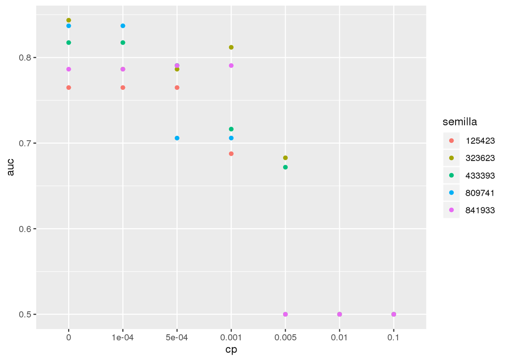

```r
# Pasamos los párametros a un factor para simplificar la visualización
resultados_cp$cp <- factor(resultados_cp$cp)
resultados_cp$semilla <- factor(resultados_cp$semilla)

ggplot(resultados_cp[type == "test"],aes(cp,auc,colour = semilla)) + geom_point()
```

Continuamos con la `Ganancia`:

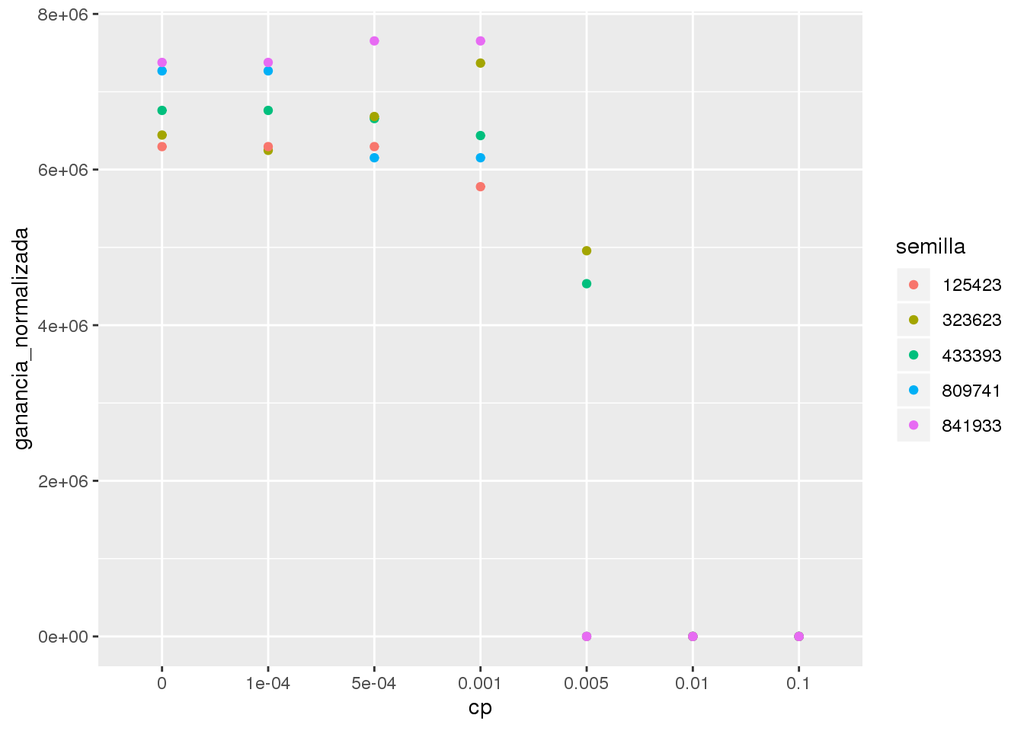

```r
ggplot(resultados_cp[type == "test"],aes(cp,ganancia_normalizada,colour = semilla)) + geom_point()
```

Y algo no menor, entender el tiempo que toma cada iteración. Nuestra vida es limita…

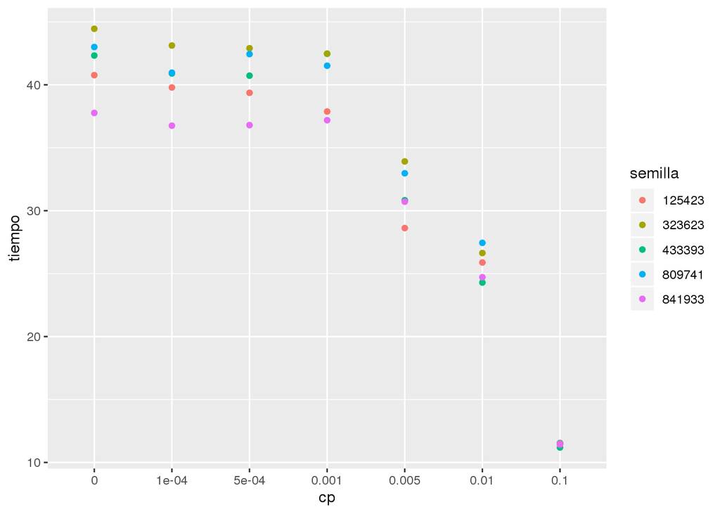

```r
ggplot(resultados_cp[type == "test"],aes(cp,tiempo,colour = semilla)) + geom_point()
```

- Si tuviera que elegir a ojo, usando las gráficas anteriores, ¿Qué `cp` eligiría? ¿Por qué?
- Repita el experimento con el resto de los parámetros.
- Sienta en su PC lo que significa en tiempo un Grid Search. Determine cúal es el mejor modelo y aplique el mismo a `abril`.
- Dude del mejor modelo, y aplique los siguiente 9 a `abril`.